# Confidence Interval for 1 proportion

Mike Hitchman

10/06/2021

### The Scene

This page helps with finding a level $C$ confidence interval for a population proportion.

A confidence interval for $p$ has the form

$$\hat{p} \pm z^* \cdot \text{SE}$$
where

- $\hat{p}$, a sample proportion, is a point estimate for $p$. If $n$ is the size of the sample, and $x$ is the number of “successes” in the sample, then $\hat{p} = x/n.$
- $z^*$ is the Z-score in $N(0,1)$ such that $P(-z^* < Z < z^*)=C$

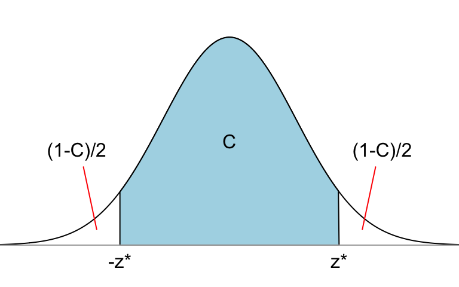

- SE $= \sqrt{\frac{p(1-p)}{n}}$. In practice, with $p$ unknown we approximate SE by using $\hat{p}$ for $p$.

### The Example

We can follow the Prepare-Check-Calculate-Conclude procedure:

**Prepare** for the interval: Our sample size is $n = 64$, and $\hat{p}=47/64.$

**Check** success-failure conditions: we had 47 “successes” and 17 “failures”, both at least 10 so the distribution for $\hat{p}$ is nearly normal.

**Calculate** the confidence interval with…

### The code

```r
n=64 #sample size
x=47 #successes
C = .95 # confidence level
phat = x/n
SE = sqrt(phat*(1-phat)/n)
zstar = qnorm(C + (1-C)/2)
MOE = zstar*SE
phat + c(-MOE,MOE) #Confidence Interval
```

```
## [1] 0.626169 0.842581
```

```r
# We can also ask Rstudio to print a summary:
cat(paste0("phat = ",round(phat,4),"\n","z* = ",round(zstar,3),"\n",
           "MOE = ",round(MOE,4),"\n",
           C*100,"% confidence interval for p: ",round(phat -MOE,4), " to ", round(phat+MOE,4),"."))
```

```
## phat = 0.7344
## z* = 1.96
## MOE = 0.1082
## 95% confidence interval for p: 0.6262 to 0.8426.
```

**Conclude.** We are 95% confident that between 62.6% and and 84.2% of Linfield students like the number 8 better than the number 3.

### Finding sample size for a particular margin of error

We know that the margin of error (MOE) for a level C confidence interval is
$$\text{MOE} = z^*\sqrt{\frac{p(1-p)}{n}}.$$
This means that we can adjust the margin of error by choosing a different sample size $n$. The larger $n$ gets, the smaller the MOE gets.

The formula we derived in class for the value of $n$ is
$$n = p(1-p)\left(\frac{z^*}{\text{MOE}}\right)^2$$
where we be sure to round up to the next whole number (e.g., if the formula gives $n = 76.2$ we should choose sample size $n=77$).

```r
C = .8 # input confidence level here (as a decimal)
p = 1/2 # input assumed value of p here.
MOE = .02 # input the desired margin of error here.
zstar = qnorm(C+(1-C)/2)
n = p*(1-p)*(zstar/MOE)^2
print(paste("The sample size must be at least",ceiling(n)))
```

```
## [1] "The sample size must be at least 1027"
```

### prop.test()

The `prop.test()` function in R generates a confidence interval as well. This function uses a slightly different formula for the CI than the one in the text, and the results of the two versions of the formula may differ slightly. **On WeBWorK and on exams use the textbook “by hand” approach.**

```r
prop.test(x=47, n=64, conf.level=.95,correct=FALSE)
```

```
##
##  1-sample proportions test without continuity correction
##
## data:  47 out of 64, null probability 0.5
## X-squared = 14.062, df = 1, p-value = 0.0001768
## alternative hypothesis: true p is not equal to 0.5
## 95 percent confidence interval:
##  0.6151713 0.8270362
## sample estimates:
##        p
## 0.734375
```

- $x$ is the number of successes (preferring 8 to 3 in this case)
- $n$ is the sample size
- conf.level is the confidence level :)
- the *correct* option (FALSE or TRUE) indicates whether or not you want to specify a “continuity correction.”